# Under the Hood II - Pseudotemporal Ordering / Trajectory Inference

The Single Cell Users Group

15/04/2019

# Pseudotemporal Ordering / Trajectory Inference

We begin by setting some global constants. We will work with dataset from the mouse cell atlas which is widely used in examples. This input data is already in the form of count matrices and will be assumed to reside in the data subdirectory of the base_directory. Since the datasets we are using are moderately large, we will be caching intermediate results; cached data will assumed to reside in the cache subdirectory of the base_directory. This mark-down as well as a set of convenience functions needed by this mark-down will be assumed to reside in the R subdirectory of the base_directory. Overall the file structure expected by this mark-down looks as follows:

| +– cache +– classifer +– data +– output +– R

In the following, we set the location of the base directory, source the R script containing the convenience functions and specify whether or not to force recalculation of intermediate results.

*NOTE: These settings need to be modified for your personal implementation.*

[output not shown]

[output not shown]

[output not shown]

[output not shown]

[output not shown]

## Read in Selected Data

The data is originates from the paper by S. Lai et al (Cell Discovery 4(2018):34). The raw sequencing data and digital gene expression (DGE) data are accessible through the Gene Expression Omnibus (GEO), accesssion code GSE92274. In this mark down we use only the DGE data.

```
## Obtaining data from GSM2869492_Mouse_BM_5  ... Done.
```

## Basic Filtering

We’ll do some basic filtering to eliminate dead and poor quality cells. Filter features that are not present in more than specified fraction of cells. Filter cells that have more than specified percentage of mitochondrial reads or have number of reads below specified quantile in the distribution of reads by cell,

```
## Filtering  GSM2869492_Mouse_BM_5  ... Done.
```

## Merge Data

```
## Processing library:  GSM2869492_Mouse_BM_5  ... Done.
```

## Cluster the Merged Data

```
## Scaling data matrix
```

```
## PC_1
```

```
## Positive: Cd74, Hba-a2, Hbb-bs, Hba-a1, Hbb-bt, H2-Aa, H2-Ab1, H2-Eb1, Igkc, Ccl5
```

```
##    Bpgm, Trbc2, H2-DMb2, Fcmr, Ighd, Ltb, Gm8369, Gzma, Trbc1, Cd79a
```

```
##    Thy1, Ccr7, Cd3d, Fcer2a, Ms4a4b, Cd8b1, Gimap6, Trac, Cd3g, Iglc3
```

```
## Negative: Tuba1b, Ptma, Prtn3, Serbp1, H2afz, Ran, Atpif1, Hsp90aa1, Slc25a5, Npm1
```

```
##    Rps5, Eif5a, Eef1b2, Rps17, Rps27l, Rps26, Rps8, Ppia, Ybx1, Rplp0
```

```
##    Rps4x, Stmn1, Atp5g1, Pclaf, Rps2, Rack1, Ctsg, Anp32b, Cdk4, Rpl36al
```

```
## PC_2
```

```
## Positive: Hbb-bt, Hba-a1, Hba-a2, Hbb-bs, Car2, Gypa, Slc4a1, Alas2, Rhd, Ctse
```

```
##    Prdx2, Hemgn, Hmbs, Blvrb, Isg20, Aqp1, Snca, Klf1, Fech, Ermap
```

```
##    Mgst3, Cldn13, Alad, Cpox, Ube2l6, Tfrc, Glrx5, Slc25a37, Bpgm, Hebp1
```

```
## Negative: Camp, Ngp, Ltf, Elane, Mpo, Wfdc21, Prtn3, Anxa1, Serpinb1a, Ctsg
```

```
##    Chil3, Ly6c2, Plac8, Hmgn2, Ms4a3, Cd63, Retnlg, Mmp8, Fcnb, Gstm1
```

```
##    Cmtm7, Lta4h, Clec12a, Nkg7, Ppia, Cebpe, Fos, Cst7, Tmed3, Prss57
```

```
## PC_3
```

```
## Positive: Cd74, Ms4a4b, Trbc2, H2-Ab1, H2-Aa, Rps29, Gm4149, Rps23, Rps18, Trbc1
```

```
##    H2-Eb1, Rps7, Thy1, Rps28, Lck, Cd3g, Cd8b1, Trac, Hba-a2, Gimap6
```

```
##    Eef1a1, Cd3d, Ccl5, Hbb-bs, Ccr7, Lat, Rps3a1, Hba-a1, Ighm, Rplp2
```

```
## Negative: Ngp, Camp, Retnlg, Chil3, Ltf, Wfdc21, Anxa1, Mmp8, Ly6c2, mt-Rnr2
```

```
##    Cd63, Cd24a, Fcnb, Elane, Mmp9, Mpo, Serpinb1a, Hmgn2, Cebpe, AA467197
```

```
##    Mrgpra2b, Itgb2l, Tuba4a, Slfn4, G0s2, St3gal5, Adpgk, Ffar2, Trem3, Gpx1
```

```
## PC_4
```

```
## Positive: Gm10123, Gm13588, Gm11808, Rps3a2, Rpl18-ps1, Oaz1-ps, RP23-288C18.3, Rps25-ps1, Rpl9-ps6, Rps15a-ps6
```

```
##    Gm8203, Rps26-ps1, Gm3511, Rps6-ps4, Gm7600, Gm7808, Gm12481, Rpl6l, Gm9800, Gm5586
```

```
##    Rps6-ps3, Rpl19-ps11, Rps19-ps6, Rps27rt, Gm5905, Gm14303, Ftl1-ps1, Camp, Gm12918, Gm6472
```

```
## Negative: Hbb-bs, Hba-a1, Hba-a2, Hbb-bt, Rpl18, Ccl5, Calr, Trbc2, Ms4a4b, Nkg7
```

```
##    Cd3g, Cd8b1, Rplp1, Cdk6, Rpl17, Prtn3, Igha, Lat, Trac, Trbc1
```

```
##    Cd74, Cst7, Rps5, Thy1, Igfbp4, Gzma, Vat1, Gimap3, Dgka, Ms4a6b
```

```
## PC_5
```

```
## Positive: Car1, Klf1, Fam132a, Dut, Hebp1, Nkg7, Hmgb3, Alad, Serpinb1a, Ctse
```

```
##    Cd79a, Smim1, Hmgn2, Pla2g12a, Rrm2, Ifrd2, Cela1, Chchd10, Dtymk, Trbc2
```

```
##    Rfc4, Ms4a3, Tk1, Cldn13, Slc38a5, Nme4, Sfxn1, Tipin, Mns1, Trbc1
```

```
## Negative: S100a4, Ms4a6c, Ctss, Psap, F13a1, Ccr2, Fn1, Cdkn1a, Cst3, Mpeg1
```

```
##    Ccl9, Wfdc17, Tgfbi, Ctsc, Atf3, Clec4a3, Vim, Cd14, Crip1, Pld4
```

```
##    Ifi30, mt-Rnr2, Prg2, Ly6c2, Cd68, Nr4a1, Atp2b1, Clec7a, Csf1r, Nfkbia
```

```
## Elapsed time: 57 seconds
```

## Batch Correction Strategies

For the datasets used in this example, we do not have information on how the sequencing was done. We have annotated with some phony batch numbers. Since the datasets are large and computations are slow, we shall downsample the data.

```
## Scaling data matrix
```

```
## Scaling data matrix
```

```
## PC_1
```

```
## Positive: Hba-a2, Hbb-bs, Hba-a1, Hbb-bt, Cd74, H2-Aa, H2-Ab1, H2-Eb1, Bpgm, Trbc2
```

```
##    Ighd, H2-DMb2, Ccl5, Gzma, Alas2, Fcmr, Trbc1, Cd8b1, Ltb, Trac
```

```
##    Cd3g, Thy1, Ccr7, Ms4a4b, Fcer2a, Gimap3, Cd79a, Ms4a1, Cd3d, Iglc3
```

```
## Negative: Tuba1b, Prtn3, Ptma, H2afz, Serbp1, Hsp90aa1, Ran, Slc25a5, Rps17, Ybx1
```

```
##    Ppia, Eif5a, Pclaf, Atpif1, Rps5, Eef1b2, Npm1, Stmn1, Rps27l, Atp5g1
```

```
##    Rps26, Hspa8, Rps8, Rack1, Plac8, Rps4x, Cdk4, Rplp0, Eef1a1, Ranbp1
```

```
## PC_2
```

```
## Positive: Hbb-bt, Hba-a2, Hba-a1, Hbb-bs, Gypa, Car2, Alas2, Ctse, Slc4a1, Rhd
```

```
##    Prdx2, Hmbs, Klf1, Isg20, Hemgn, Fech, Snca, Aqp1, Blvrb, Cpox
```

```
##    Ermap, Cldn13, Bpgm, Ube2l6, Mgst3, Alad, Hebp1, Glrx5, Dhrs11, Slc25a37
```

```
## Negative: Camp, Ngp, Ltf, Mpo, Elane, Chil3, Ly6c2, Anxa1, Hmgn2, Serpinb1a
```

```
##    Mmp8, Plac8, Ctsg, Cd63, Prtn3, Ms4a3, Fcnb, Fos, Lta4h, Gstm1
```

```
##    Cebpe, Cst3, Ppia, Nkg7, Clec12a, Tmed3, Psap, Igkc, Prss57, G0s2
```

```
## PC_3
```

```
## Positive: Cd74, Ms4a4b, Trbc2, Gm4149, Rps29, Rpl19-ps11, Gm14303, H2-Ab1, Trbc1, Trac
```

```
##    H2-Aa, Thy1, Rps28, Gm15427, Lck, Rps3a2, Rps27rt, Cd3g, Rps23-ps1, Rps15a-ps6
```

```
##    Rps23, Rps6-ps4, Ms4a6b, Rps18, Cd3d, H2-Eb1, Rps15a-ps7, H2-Q7, Gm7600, Gm10123
```

```
## Negative: Ngp, Camp, Chil3, Ltf, Ly6c2, Anxa1, Mmp8, Cd63, Fcnb, Elane
```

```
##    Mpo, Serpinb1a, Igha, Cebpe, Tuba4a, Gpx1, Mrgpra2b, AA467197, Itgb2l, Ffar2
```

```
##    G0s2, Ms4a3, Hmgn2, Prg2, Ctse, C3, Prss34, Atpif1, Clec4e, Car2
```

```
## PC_4
```

```
## Positive: Ms4a4b, Trbc2, Trac, Cd3g, Lck, Ms4a6b, Lat, Trbc1, Cd8b1, Thy1
```

```
##    Rpl3, Rpl36a, Ccl5, Rps5, Rps2, Cd74, Rps18, Cd3d, Rpl12, Gimap3
```

```
##    Rplp0, Hbb-bs, Rps23, Ccr7, Gimap4, Nkg7, Dapl1, Eef1a1, Skap1, Gzma
```

```
## Negative: Camp, Ngp, Gm10123, Gm13588, Rps15a-ps6, Oaz1-ps, Gm11808, Rpl18-ps1, Chil3, Ltf
```

```
##    Rps3a2, Rpl19-ps11, Ftl1-ps1, Rps6-ps3, Gm3511, Rps26-ps1, Gm12481, Gm7808, Rpl9-ps6, Gm5637
```

```
##    Gm12854, Gm8203, Rps25-ps1, Rps27rt, Rps6-ps4, Rps15a-ps7, Gm9800, Gm7600, Rpl35a-ps2, Mmp8
```

```
## PC_5
```

```
## Positive: Nkg7, Car1, Hmgb3, Klf1, Mthfd1, Dut, Pla2g12a, Ctse, Cd79a, Fam132a
```

```
##    Nme4, Trbc2, Srm, Hebp1, Ranbp1, Lck, Dtymk, Nme1, Ms4a3, Serpinb1a
```

```
##    Alad, Chchd10, Mif, Prss57, Wdr12, Smim1, Trac, Ubac1, Trbc1, Rrm1
```

```
## Negative: S100a4, Ms4a6c, Psap, F13a1, Ctss, Cdkn1a, Ccr2, Fn1, Mpeg1, Ctsc
```

```
##    Cst3, Clec4a3, Ifi30, Tgfbi, Crip1, Vim, Ccl9, Cd68, Wfdc17, Atf3
```

```
##    Cd14, Nr4a1, Atp2b1, Ms4a4c, Prg2, Nfkbia, Csf1r, Ly6c2, Ccl3, Gpx1
```

```
## Elapsed time: 3 seconds
```

### Regression

```
## Found3batches
```

```
## Adjusting for0covariate(s) or covariate level(s)
```

```
## Standardizing Data across genes
```

```
## Fitting L/S model and finding priors
```

```
## Finding parametric adjustments
```

```
## Adjusting the Data
```

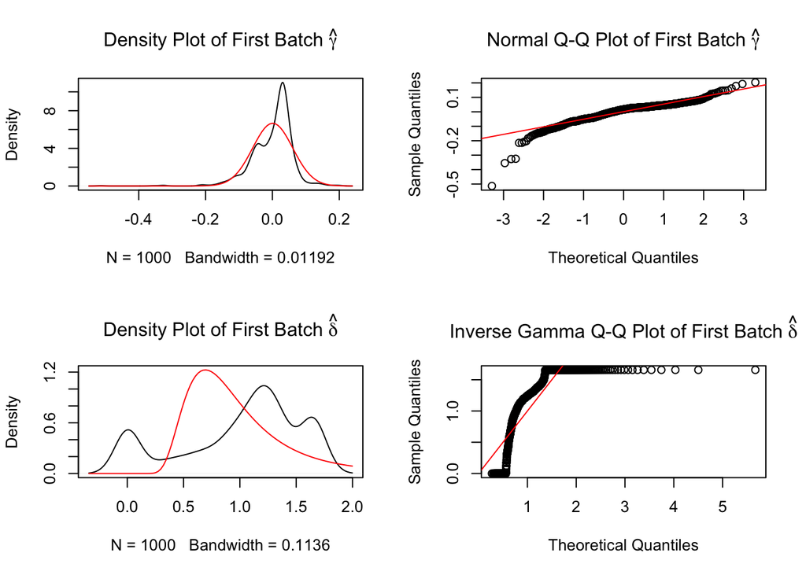

### Plot Data with Batch Effects Regressed Out

```
## Scaling data matrix
```

```
## PC_1
```

```
## Positive: Snca, Epb41, Tfdp2, Fam46c, Fam220a, Fam213a, Alas2, Bpgm, Ppp1r15a, Hba-a2
```

```
##    Rec114, Cd83, Hba-a1, Hbb-bt, Sgms1, Gpr171, Dapl1, Fech, Trac, Isg20
```

```
##    Rsad2, Ccr7, Skap1, Fcer2a, Tcf7, Ube2l6, Cd8a, Bank1, S1pr1, Cd247
```

```
## Negative: Ighg2b, Prtn3, Jchain, Cpa3, Prss57, Sdf2l1, Ruvbl2, Ctsg, Mcpt8, Rpl24
```

```
##    Kpna2, Car1, Fcer1a, Tuba8, Ms4a3, Alas1, 0610007P14Rik, Mt1, Gm26917, Cela1
```

```
##    Ccna2, Gm5586, G6pc3, Cdk6, Mgl2, Gm14165, Tk1, Cenpk, Gm12854, Ccnb1
```

```
## PC_2
```

```
## Positive: Col1a2, Sparc, Col1a1, Ear6, Gm23935, Epx, Ear1, Tmcc2, Xpo7, Trim10
```

```
##    Prg2, C1qc, Tmod1, Epb42, Bglap, Slfn14, Cd36, Gch1, Prg3, Cxcl10
```

```
##    Kel, Diaph3, Hbq1b, Fam210b, Pdzk1ip1, Apol11b, Specc1, Chac2, Rhag, Spta1
```

```
## Negative: Mettl1, Gm10132, Rpl19-ps11, Cbr1, Noc4l, Fam53a, Igtp, Rps15a-ps4, Gm3788, Rtp4
```

```
##    Bcl2, Abi3, Phf11b, Gm4332, Il7r, Nkg7, Cpa3, Fcer1a, Gimap4, Mgl2
```

```
##    Cela1, Gpr160, Nme4, Gm14165, Cd34, Lck, Tuba8, Chchd4, Nup37, Bphl
```

```
## PC_3
```

```
## Positive: Klrd1, Skap1, Fcer2a, Bank1, Dapl1, S1pr1, Cd8a, Cd247, Tcf7, Klra8
```

```
##    Klra4, Prf1, Trac, Sh2d2a, Il2rb, Pkp3, BE692007, Ace, Klrb1c, Cd4
```

```
##    Cd3g, Klra13-ps, Cd8b1, Cd200, Lat, Trib2, Cx3cr1, Gimap3, Ighd, Faah
```

```
## Negative: Gpx1, Rps17, Slc25a5, Serbp1, H2afz, Tuba1b, Ptma, Rack1, Ppia, Hspa8
```

```
##    Rps5, Rpl36al, Rps4x, Atpif1, Rps8, Eif5a, Hsp90aa1, Eef1b2, Ran, Rps27l
```

```
##    Rps26, Rplp0, Ly6c2, Tuba4a, Hsp90ab1, Rpl7a, Pclaf, Npm1, Atp5g1, Tmem256
```

```
## PC_4
```

```
## Positive: Ngp, Camp, Ltf, Chil3, Anxa1, AA467197, Mmp8, Itgb2l, Hbb-bs, Hba-a1
```

```
##    Hbb-bt, Hba-a2, G0s2, Mrgpra2b, Orm1, Fcnb, Cebpe, Fpr1, Jchain, Ffar2
```

```
##    Krt83, Prss34, Serpinb1a, Gadd45g, Clec4e, Ighg2b, Cd63, C3, Cxcr2, Mgll
```

```
## Negative: Rps18, Rps23, Rps2, Rps29, Eef1a1, Rps26, Rpl3, Rps28, Eef1b2, Npm1
```

```
##    Rpl22, Rpl39, Rps5, Rpl36a, Ppia, Rplp0, Rps6, Rpl27, Rps12, Rpl12
```

```
##    Rps4x, Gas5, Rpl22l1, Rps8, Slc25a5, Rps17, Eef1g, Ptma, Rpl36al, Serbp1
```

```
## PC_5
```

```
## Positive: Car2, Prdx2, Ctse, Glrx5, Klf1, Rhd, Hbb-bt, Hba-a1, Hmbs, Gypa
```

```
##    Nme4, Srm, Blvrb, Alad, Cela1, Ermap, Hba-a2, Hebp1, Atpif1, Cpox
```

```
##    Hbb-bs, Aqp1, Ubac1, Metap2, Mthfd1, Fech, Atad3a, Hemgn, Pebp1, Cldn13
```

```
## Negative: Rps15a-ps6, Gm10123, Rpl18-ps1, Rps3a2, Gm13588, Rps26-ps1, Gm11808, Rps27rt, Rps15a-ps7, Ftl1-ps1
```

```
##    Rps6-ps4, Gm7600, Gm5905, Gm12481, Gm7536, Rps24-ps3, Gm6472, Rpl9-ps6, Oaz1-ps, Gm1821
```

```
##    Rps19-ps6, Gm14303, Gm7808, Psap, Gm8797, Rpsa-ps10, Ctss, Gm9800, Gm15501, Rpl35a-ps2
```

```
## Elapsed time: 3 seconds
```

### Mutual Nearest Neighbors

Another approach for batch correction is to use mutual nearest neighbors

[output not shown]

[output not shown]

[output not shown]

[output not shown]

## Plot the MNN batch-corrected data

```
## Scaling data matrix
```

```
## PC_1
```

```
## Positive: Ngp, Camp, Serpinb1a, Chil3, Psap, Ighm, Igkc, Ltf, Crip1, Gm1821
```

```
##    Elane, Srgn, Itgb2l, Vim, Cebpe, Gstm1, H2-Q10, Ly6d, Iglc1, Dbi
```

```
##    G0s2, C3, H2afy, Mrgpra2b, Irf8, Rps6-ps4, Ramp1, Rtp4, Fcna, Cdk14
```

```
## Negative: Cldn13, Rhd, Klf1, Ctse, Cpox, Gypa, Hebp1, Alad, Gypc, Car2
```

```
##    Hemgn, Mgst3, Rfesd, Tspo2, Hmbs, Mns1, Aqp1, Tfrc, Ubac1, Slc25a37
```

```
##    Slc4a1, Cela1, Hagh, Pla2g12a, Dhrs11, Isg20, Car1, Gata1, Slc29a1, Gpsm2
```

```
## PC_2
```

```
## Positive: Isca1, Hbb-bs, Rgs1, Pola1, Nup35, Dhrs11, Cdc7, Supt3, Gata1, Slc25a37
```

```
##    Hagh, Hba-a2, Pla2g12a, Brpf3, Hemgn, Cpsf2, Ak3, Pds5b, Hba-a1, Tada3
```

```
##    Gusb, Fbxo18, Fech, Mgst3, Esco2, Gypa, Ubac1, Smox, Gm14165, Slc29a1
```

```
## Negative: Gm10177, Gm6472, Klk1, RP24-338A5.4, Gins2, Fahd2a, Rad51d, Washc5, Nup37, Gm2225
```

```
##    Gm10131, Gm10132, Aif1, Cox6a2, Siglech, Ccdc86, Trp53i11, Hibadh, Rpl18-ps2, Sumo2
```

```
##    RP23-70B19.5, Tmem176a, Gm5805, C1qb, Clec4a3, 2810004N23Rik, Atp5g2, Tmem176b, Hscb, Sdf2l1
```

```
## PC_3
```

```
## Positive: Ces2g, Cmc1, Ncapg, Ppp1r14b, Aggf1, Nme6, Selenbp1, Ppa1, Rnaseh2a, Rps6kb1
```

```
##    Snhg4, Paics, Rpf2, Mad1l1, Rfc3, Gm10039, Hacd1, Egfl7, Sacm1l, Adsl
```

```
##    Ptrh2, Nme4, Rrp15, Mt2, Bcat2, Sfxn1, Gclc, Snrpf, Sde2, Spint2
```

```
## Negative: Gemin2, Rpl21-ps15, Clec4a1, Tcf4, Mef2d, Dusp2, Tcf3, Rpl37rt, Chst15, Bod1l
```

```
##    RP24-338A5.4, Washc5, Tmem176a, Iglv1, Trim30b, Gm10177, Ddx1, H2-Eb1, Pola1, St3gal6
```

```
##    Rnase6, Rgs1, Fut7, Cd200, Gm6472, Siglech, Sil1, Neil3, Klk1, Gm10076
```

```
## PC_4
```

```
## Positive: Pex3, Rpl13-ps6, Arsb, Gpr160, AI839979, Tuba8, Ddx19a, Prosc, Tars, Ppif
```

```
##    Hmga1, Fcer1a, 1600020E01Rik, Cd8b1, Slc30a7, Gm10036, Fbxo18, Tada3, Chchd6, Hmox1
```

```
##    Rps3a2, Hadhb, Ube2n, Myl10, Bzw2, Prpf4b, Rwdd1, Dntt, Hacd1, Spint2
```

```
## Negative: Cmc1, Tspan33, Lmna, Gclc, Sde2, Gm10039, Snrnp200, Phf10, Bcat2, Oaz1-ps
```

```
##    Uck2, Grhpr, Rfc3, Lsm3, Adsl, Zfp131, Slc31a1, Gpsm2, Rad51d, Gstm5
```

```
##    Mybbp1a, Gtf2f2, Bub1b, Timm9, Sumo2, Gm8430, Nudcd2, Rwdd4a, Gm8451, Noc4l
```

```
## PC_5
```

```
## Positive: BC003965, Mif, Plac8, Etfb, Gm26917, Mrps6, Prtn3, Lta4h, P4hb, Eprs
```

```
##    Ssr4, Gm7536, Hsp90ab1, Hspa5, Hnrnpa3, Ctsg, Phb2, Calr, Smc2, Ms4a3
```

```
##    Nop56, Rpl39, Nkg7, Manf, Gm14303, Larp1, Snhg3, Rpl12, Eif2s2, Npm1
```

```
## Negative: Aggf1, Ces2g, Rwdd4a, Rpl13-ps6, Nxpe2, Mad1l1, Rad51d, Cd8b1, Tada3, Nudt9
```

```
##    Cd4, Snrnp200, Cmc1, Fbxo18, Minpp1, Myl10, Chchd6, Wdr12, Ly6a, Stard10
```

```
##    Lck, Sumo2, Sacm1l, Ube2n, H2-DMb2, Lsm3, Skap1, Bcat2, Grhpr, Gm10039
```

```
## Elapsed time: 3 seconds
```

## Integrating the Data

```
## Computing 2000 integration features
```

```
## Scaling features for provided objects
```

```
## Finding all pairwise anchors
```

```
## Running CCA
```

```
## Merging objects
```

```
## Finding neighborhoods
```

```
## Finding mutual nearest neighborhoods
```

```
##  Found 19310 anchors
```

```
## Filtering Anchors
```

```
##  Retained 1444 anchors
```

```
## Extracting within-dataset neighbors!
```

```
## Running CCA
```

```
## Merging objects
```

```
## Finding neighborhoods
```

```
## Finding mutual nearest neighborhoods
```

```
##  Found 17277 anchors
```

```
## Filtering Anchors
```

```
##  Retained 1259 anchors
```

```
## Extracting within-dataset neighbors!
```

```
## Running CCA
```

```
## Merging objects
```

```
## Finding neighborhoods
```

```
## Finding mutual nearest neighborhoods
```

```
##  Found 18617 anchors
```

```
## Filtering Anchors
```

```
##  Retained 1920 anchors
```

```
## Extracting within-dataset neighbors!
```

```
## Running CCA
```

```
## Merging objects
```

```
## Finding neighborhoods
```

```
## Finding mutual nearest neighborhoods
```

```
##  Found 13769 anchors
```

```
## Filtering Anchors
```

```
##  Retained 1791 anchors
```

```
## Extracting within-dataset neighbors!
```

```
## Running CCA
```

```
## Merging objects
```

```
## Finding neighborhoods
```

```
## Finding mutual nearest neighborhoods
```

```
##  Found 15875 anchors
```

```
## Filtering Anchors
```

```
##  Retained 800 anchors
```

```
## Extracting within-dataset neighbors!
```

```
## Running CCA
```

```
## Merging objects
```

```
## Finding neighborhoods
```

```
## Finding mutual nearest neighborhoods
```

```
##  Found 15741 anchors
```

```
## Filtering Anchors
```

```
##  Retained 1359 anchors
```

```
## Extracting within-dataset neighbors!
```

```
## Running CCA
```

```
## Merging objects
```

```
## Finding neighborhoods
```

```
## Finding mutual nearest neighborhoods
```

```
##  Found 14379 anchors
```

```
## Filtering Anchors
```

```
##  Retained 2018 anchors
```

```
## Extracting within-dataset neighbors!
```

```
## Running CCA
```

```
## Merging objects
```

```
## Finding neighborhoods
```

```
## Finding mutual nearest neighborhoods
```

```
##  Found 16543 anchors
```

```
## Filtering Anchors
```

```
##  Retained 817 anchors
```

```
## Extracting within-dataset neighbors!
```

```
## Running CCA
```

```
## Merging objects
```

```
## Finding neighborhoods
```

```
## Finding mutual nearest neighborhoods
```

```
##  Found 16421 anchors
```

```
## Filtering Anchors
```

```
##  Retained 1406 anchors
```

```
## Extracting within-dataset neighbors!
```

```
## Running CCA
```

```
## Merging objects
```

```
## Finding neighborhoods
```

```
## Finding mutual nearest neighborhoods
```

```
##  Found 18446 anchors
```

```
## Filtering Anchors
```

```
##  Retained 3973 anchors
```

```
## Extracting within-dataset neighbors!
```

```
## Merging dataset 5 into 4
```

```
## Extracting anchors for merged samples
```

```
## Finding integration vectors
```

```
## Finding integration vector weights
```

```
## Integrating data
```

```
## Merging dataset 2 into 3
```

```
## Extracting anchors for merged samples
```

```
## Finding integration vectors
```

```
## Finding integration vector weights
```

```
## Integrating data
```

```
## Merging dataset 1 into 4 5
```

```
## Extracting anchors for merged samples
```

```
## Finding integration vectors
```

```
## Finding integration vector weights
```

```
## Integrating data
```

```
## Merging dataset 3 2 into 4 5 1
```

```
## Extracting anchors for merged samples
```

```
## Finding integration vectors
```

```
## Finding integration vector weights
```

```
## Integrating data
```

## Plot

```
## Scaling data matrix
```

```
## PC_1
```

```
## Positive: Retnlg, Mmp8, Mmp9, Ltf, Slfn4, Cd74, Gm13588, Il1b, Gstm5, Oas3
```

```
##    AA467197, Dscc1, Osm, Gm9844, Scamp1, Plbd1, Ngp, Nxpe2, Acvrl1, Kbtbd3
```

```
##    Nudt8, Adam8, Minpp1, Fpr1, Kctd14, Gm3788, Dtx3, Padi4, Rps10-ps1, Thbs1
```

```
## Negative: Rps2, Rplp0, Rps3a1, Rps8, Rpl14, Rps26, Rplp1, Rps5, Rpl3, Rps3
```

```
##    Rpl18, Rpl26, Slc25a5, mt-Nd1, mt-Cytb, Rps7, Rps4x, Rps12, Rps23, Gpx1
```

```
##    Rps17, Eef1a1, Rack1, Hspa8, Atp5g1, Ptma, Eif5a, Rps25, Tuba1b, Serbp1
```

```
## PC_2
```

```
## Positive: Elane, Prtn3, Mpo, Ctsg, Ms4a3, Srgn, Gstm1, Ly6c2, Nkg7, Plac8
```

```
##    Cd63, Cst7, Cmtm7, Serpinb1a, Prss57, Tmed3, Lta4h, P4hb, Calr, Clec12a
```

```
##    Dbi, Ap3s1, Ramp1, Krtcap2, Gng12, Pdia6, Mgl2, Anxa3, Igfbp4, Fcnb
```

```
## Negative: Car2, Ctse, Blvrb, Prdx2, Alad, Cldn13, Hmbs, Hebp1, Rhd, Aqp1
```

```
##    Klf1, Tmem14c, Glrx5, Gypa, Car1, Mgst3, Hemgn, Tspo2, Cpox, Atpif1
```

```
##    Smim1, Pigq, Ubac1, Cd24a, Urod, Fam132a, Isg20, Slc4a1, Slc38a5, Rfesd
```

```
## PC_3
```

```
## Positive: Camp, Ngp, Chil3, Fcnb, Serpinb1a, Wfdc21, Hmgn2, Cd63, Ltf, Cebpe
```

```
##    Lta4h, Anxa1, Tuba4a, Elane, Hsd11b1, Mgst2, Ms4a3, Rgcc, Trem3, Clec12a
```

```
##    Ube2c, Hmgb2, Tmem216, Prss57, Ffar2, Gpx1, Agpat2, 1810037I17Rik, Nkg7, Tmed3
```

```
## Negative: Npm1, Crip1, Hspe1, Prdx1, Mif, Ms4a6c, C1qbp, Slc25a4, Lgals1, Cdk4
```

```
##    Fabp5, S100a10, Gas5, Dctpp1, Srm, Bzw2, Cd34, Ctss, Chchd10, Irf8
```

```
##    Igll1, Hmgn1, Pebp1, Zfas1, Psap, H2afy, Cct3, F13a1, Prdx4, Hspa8
```

```
## PC_4
```

```
## Positive: Crip1, Psap, Ms4a6c, F13a1, Pclaf, Cst3, Lgals1, S100a4, Ctss, Ifi30
```

```
##    Vim, C1galt1c1, S100a10, Ccr2, Mpeg1, Hmgb2, Tgfbi, Chil3, Klf4, Irf8
```

```
##    Pld4, Fos, H2afz, Prdx4, Racgap1, H2afv, Hmgb1, H2afx, Vpreb3, Fn1
```

```
## Negative: Mpo, Mt1, Ctsg, Srgn, Elane, Nkg7, Cst7, Car1, Ms4a3, Prss57
```

```
##    Prtn3, Calr, Srm, Retnlg, Rgcc, Fam132a, Car2, Gstm1, C1qbp, Mthfd1
```

```
##    Mmp8, Fkbp11, Cd63, Smim1, Atpif1, Atp5g1, Slc38a5, Cldn13, Ppid, Blvrb
```

```
## PC_5
```

```
## Positive: Psap, Ms4a6c, Gpx1, Ctss, Plac8, Gstm1, Ctsg, F13a1, Prtn3, Cst3
```

```
##    Ly6c2, S100a4, Elane, Mpo, Srgn, Nkg7, Ccl9, Ccr2, Mpeg1, Lgals1
```

```
##    Mgst3, Ctse, Tgfbi, Cst7, Ms4a3, Hmbs, C1galt1c1, Ifi30, Fn1, Pld4
```

```
## Negative: Ngp, Camp, Ltf, Chil3, Wfdc21, Anxa1, Igll1, Chchd10, Vpreb3, Vpreb1
```

```
##    Hmgn2, Pclaf, Itgb2l, Lrmp, Adpgk, Myl4, Fcnb, Npm1, Stmn1, Hmgb1
```

```
##    Bfsp2, Hmgn1, AA467197, Cebpe, Marcksl1, Orm1, Ffar2, Pafah1b3, Ptma, Zmpste24
```

```
## Elapsed time: 82 seconds
```

## Monocle Analysis

We convert the data from Seurat objects to CellDataSets

### Dimensionally reduce

Dimensionally reduce the CellDataSet

```
## Removing 209 outliers
```

```
## the first element will be used
```

```
##   -k is set to 230
```

```
## Running louvain iteration  1 ...
```

```
## Run kNN based graph clustering DONE, totally takes 3.16652388572693 s.
```

```
##   -Number of clusters: 18
```

### Pseudotemporally order cells

Very basic pseudotemporal ordering of cells. This is usually the departure point for studying the differential expression of genes that might regulate different developmental trajectories. We will not take this very far. In a separate Jupyter notebook we show how comparable analyses may be performed using scanpy and PAGA.